# Build in the VM, Think on the Mac GPU: Debian 13 on Apple container With a Local Gemma 4

[figure not shown]

This article walks through building a Debian 13 machine under Apple's `container` CLI on an Apple silicon Mac, and then wiring that machine to a local LLM running on the Mac's own GPU.

**The VM is where your app lives. The Mac is where the model thinks.** A Linux VM under `container` gets virtual CPUs and virtual devices and no Metal access, so running a model inside it wastes the one piece of hardware that makes a Mac good at this. The split that works is the obvious one once you see it: customize your app in a real Debian box, run it with `container machine run`, and have it call Ollama on macOS over the VM network.

Getting there has two halves, and the first one fails silently. `container machine create debian:13` succeeds. The machine is created. It just never boots, and nothing on the command line tells you why.

- The official **`debian:13` image has no `/sbin/init`**, so a machine made from it stays `stopped` forever.
- A small Dockerfile adding **`systemd-sysv`** fixes it, and two more lines stop every machine from sharing **one machine-id**.
- The VM reaches the Mac at **`192.168.64.1`**, with no port forwarding and no hostname to look up.
- Ollama must listen on **`0.0.0.0`**, and **`brew services restart` silently undoes that**.
- From inside Debian, `gemma4:e2b` answered at **45.2 tok/s**, loaded **100% on the GPU**.
- Gemma 4 thinks before it answers, so a small token limit returns an **empty reply** that looks like success.

https://github.com/xbill9/apple-container-debian-tips

#### The Machine

Everything below was run on 2026-09-13:

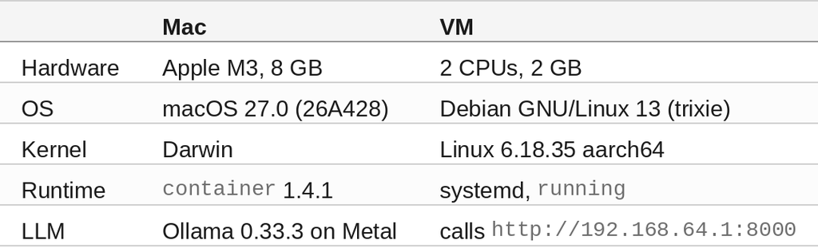

**8 GB is the constraint that shapes every choice here.** One model, one 2 GB machine, and the image builder stopped when it is not building.

#### At This Point You Should Have

- An Apple silicon Mac on macOS 26 or newer. `container` does not run on anything else.
- A real Terminal window for the two steps that need a TTY.
- Homebrew, for Ollama.
- About 1.4 GB of disk for a Debian machine image, plus the model.

#### Containers and Machines Are Not the Same Thing

This distinction caused the most confusion, so it goes first. `container` runs Linux in two ways:

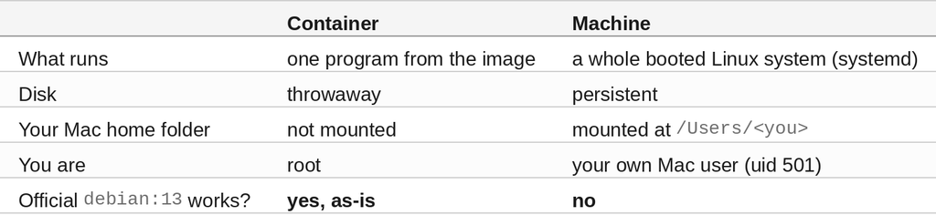

A container is fine for running one command. **A machine is what you want for an app you keep customizing** — packages you installed yesterday are still there, your source tree is already mounted, and services start under systemd like they would on any Debian server.

And `container` is not Docker. There is no Docker Desktop, no `dockerd` and no containerd process. Each container and each machine runs in its own lightweight VM, managed by Apple's own launchd agents. The images, though, are ordinary OCI images, so Docker Hub works.

#### Step 0 — Install container and a Kernel

Download the signed `.pkg` from https://github.com/apple/container/releases and verify it:

```bash
pkgutil --check-signature container-1.4.1-installer-signed.pkg
# Developer ID Installer: Apple Inc. - Containerization (UPBK2H6LZM)
# Notarization: trusted by the Apple notary service
```

**`sudo installer` needs a real TTY**, so either run it in a Terminal window or use the GUI installer:

```bash
open container-1.4.1-installer-signed.pkg
```

Then start the services. `container system start` stops to ask about downloading a Linux kernel, and a script cannot answer that prompt, so set the kernel explicitly:

```bash
container system start
container system kernel set --recommended
container system status
#    status              running
#    client.version      1.4.1
#    server.version      1.4.1
```

That pulls the Kata Containers kernel. Without it, nothing runs.

#### Step 1 — Watch the Official Image Fail to Boot

**This step exists because the failure is invisible.** Pull the image and look for an init:

```bash
container image pull docker.io/library/debian:13
container run --rm debian:13 sh -c 'ls -l /sbin/init; command -v ps ip less sudo; echo done'
ls: cannot access '/sbin/init': No such file or directory
done
```

No init, and no `ps`, `ip`, `less` or `sudo` either. A container never boots, so its image does not need an init. A machine boots a kernel, and Apple's `/sbin.machine/init` ends with a hard-coded `exec /sbin/init`. Try it anyway and the logs say so:

```bash
container machine create debian:13 --name debian13-vm   # creates, but never boots
container machine logs debian13-vm
# /sbin.machine/init: 74: exec: /sbin/init: not found
container machine delete debian13-vm
```

**`container machine logs <n>` is the first place to look when a machine will not boot.** Apple's own docs use `alpine:3.22` because BusyBox happens to provide `/sbin/init`.

#### Step 2 — Build a Debian Image That Has an Init

In an empty directory, create `Dockerfile`:

```
FROM debian:13
ENV DEBIAN_FRONTEND=noninteractive
RUN apt-get update \
    && apt-get install -y --no-install-recommends \
        systemd-sysv dbus sudo ca-certificates procps less iproute2 iputils-ping curl \
    && rm -rf /var/lib/apt/lists/*
RUN systemctl mask systemd-modules-load.service
RUN : > /etc/machine-id && rm -f /var/lib/dbus/machine-id
CMD ["/sbin/init"]
```

Every line is there because something broke without it:

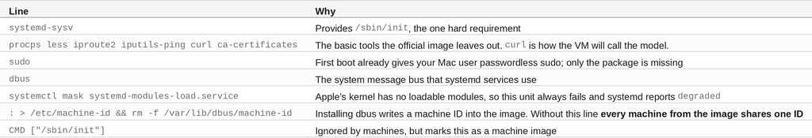

The machine-id line is the one I found the hard way. Every machine I created had the same ID, across separately built images and even from a snapshot whose `/etc/machine-id` was emptied — because systemd copies dbus's build-time copy into an empty `/etc/machine-id` at boot. Emptying one file is not enough. Remove the other.

Build it. The builder holds 2 CPUs and 2 GB while it runs, and `container build` starts it but never stops it:

```bash
container builder start
container build -t debian13-machine .
container builder stop
```

The build took about 10 seconds. `debconf: ... Readline` lines only mean there is no terminal.

#### Step 3 — Check the Image Before You Commit to It

This is the check I skipped the first time:

```bash
container run --rm debian13-machine sh -c 'ls -l /sbin/init; wc -c < /etc/machine-id; ls /var/lib/dbus/machine-id'
lrwxrwxrwx 1 root root 22 Apr 13 19:38 /sbin/init -> ../lib/systemd/systemd
0
ls: cannot access '/var/lib/dbus/machine-id': No such file or directory
```

You want `/sbin/init` present, a 0-byte machine-id, and no dbus copy. Check with `ls`, not `readlink -f` — `readlink -f /sbin/init` prints a path even when the file is missing.

#### Step 4 — Create the Machine, and Wait for It

```bash
container machine create debian13-machine --name dev-vm --cpus 2 --memory 2G
```

`create` returns in about a second, **before the VM has booted**. A command sent straight away fails with an error that points in completely the wrong direction:

```
Error: The operation couldn’t be completed. Operation not supported on socket
```

That is not a socket problem and not a TTY problem. It is a machine that has not finished booting. Poll until it answers — 13 seconds here:

```bash
until container machine run -n dev-vm --root -- true 2>/dev/null; do sleep 2; done
```

Then give systemd a few more seconds. `systemctl is-system-running` says `initializing` for a while after first boot.

#### Step 5 — Check It Is Really Running

```bash
container machine run -n dev-vm -- '. /etc/os-release; echo "$PRETTY_NAME"; uname -srm; systemctl is-system-running; id; sudo -n id -u; nproc'
Debian GNU/Linux 13 (trixie)
Linux 6.18.35 aarch64
running
uid=501(xbill) gid=20(dialout) groups=20(dialout)
0
2
```

- ✅ `running`, not `degraded` or `initializing`: systemd is fully up.
- ✅ `id`: you are your Mac user, created in the VM on first boot.
- ✅ `sudo -n id -u` printed `0`: passwordless sudo works.
- ✅ Your Mac home folder is mounted at `/Users/<you>`.

**Pass a command as one quoted argument.** `machine run` joins its arguments with spaces and re-parses them with `/bin/bash -c` inside the VM, so your host-side quoting is lost:

```bash
container machine run -n mkdm-test-vm --root -- echo '$0' 'a    b'
# /bin/bash a b          ($0 expanded in the VM, spaces collapsed)
```

So `-- sh -c '...'` silently runs the wrong command and prints nothing. The snippet is already run by bash; hand it over whole.

#### Step 6 — Customize It Like a Real Box

This is the part a container cannot do. Anything you install lives on the machine's own disk:

```bash
container machine run -n dev-vm --root -- 'apt-get update && apt-get install -y --no-install-recommends git vim-tiny'
```

And it survives a restart:

```bash
container machine stop dev-vm                         # takes about 10 s
container machine run -n dev-vm -- 'git --version'    # boots it again
# git version 2.47.3
```

After a restart, `machine run` answers before systemd does — `systemctl` said `Failed to connect to system scope bus` for the first few seconds. Wait before using it.

**Deleting the machine deletes these changes.** To keep them, add the packages to the Dockerfile and rebuild, or snapshot the machine into an image.

Interactive shells need a real Terminal window; from scripts and agent tools they fail with the same "not supported" error as Step 4:

```bash
container machine run -n dev-vm            # shell as you
container machine run -n dev-vm --root     # shell as root
```

#### The short way

Steps 2 through 5 are what `bin/mkdebian-machine` in the repo does, including the `/sbin/init` check, the boot poll, and stopping the builder if it was stopped before. A `--setup` script runs inside the new machine as root:

```bash
bin/mkdebian-machine new -t debian13-machine -m dev-vm -p sudo
bin/mkdebian-machine new -m dev-vm -p "git vim" --setup ./setup-dev.sh
```

`-p` packages are baked into the image. `--setup` changes only that machine. `bin/mkdebian-machine publish dev-vm <ref>` snapshots a hand-customized machine into an image and scrubs your user, SSH host keys and logs first.

#### Why the Model Does Not Run in the VM

**A VM gets no GPU.** Linux inside `container` sees virtual CPUs and virtual devices and has no Metal access. A model running there runs on CPU, in the 2 GB you gave the machine.

So the model runs on **macOS**, where Ollama uses the M3 GPU, and the VM calls it over the VM network:

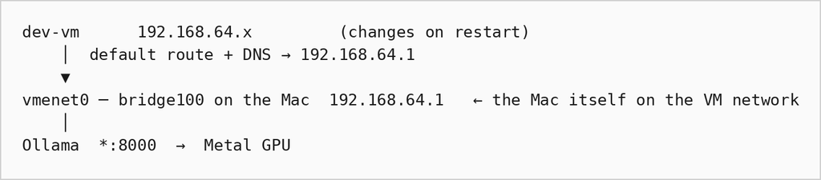

- `192.168.64.1` is the Mac's address on `bridge100`. It is the VM's gateway and DNS server, and **it did not change across VM restarts**. The VM's own address did.
- There is no `host.docker.internal` or `host.container.internal`. Use the IP.
- There is no port forwarding. The VM connects straight to the Mac, which **only works because Ollama listens on all interfaces**. On `127.0.0.1` the VM cannot reach it.

#### Step 7 — Point Ollama at the VM Network

Install Ollama and a model that fits in 8 GB:

```bash
brew install ollama
brew services start ollama
OLLAMA_HOST=127.0.0.1:8000 ollama pull gemma4:e2b
```

Ollama runs as a Homebrew launchd service. This Mac's plist had already been customized to port 8000 with `OLLAMA_KV_CACHE_TYPE=q4_0` and `OLLAMA_FLASH_ATTENTION=1`, so only the host changes. Homebrew's own default is `127.0.0.1:11434`; set port 8000 too, or adjust the URLs below.

```bash
P=~/Library/LaunchAgents/homebrew.mxcl.ollama.plist
cp -p "$P" "$P.bak-$(date +%Y%m%d%H%M%S)"
/usr/libexec/PlistBuddy -c 'Set :EnvironmentVariables:OLLAMA_HOST 0.0.0.0:8000' "$P"

# restart so launchd rereads the plist
launchctl bootout gui/$(id -u)/homebrew.mxcl.ollama
launchctl bootstrap gui/$(id -u) "$P"

lsof -nP -iTCP:8000 -sTCP:LISTEN     # ollama  *:8000
```

**Do not use `brew services restart ollama`.** It regenerates the plist from the formula, which sets only `OLLAMA_FLASH_ATTENTION=1` and `OLLAMA_KV_CACHE_TYPE=q8_0`. That silently puts `OLLAMA_HOST` back to localhost — and the VM stops reaching the model with no change on the VM side at all.

This setup is open on purpose. With `0.0.0.0` and the macOS application firewall off, Ollama was also reachable from the Wi-Fi network. For a demo on a home network that is the point. Anywhere else, it is the first thing to change.

#### Step 8 — Test the Mac Side First

`bin/test-mac-ollama` checks Ollama on the Mac without a VM involved: the listener, localhost and `192.168.64.1`, the plist, the native, streaming and OpenAI-compatible APIs, and GPU placement. It unloads the models on exit and exits 0 only when every check passes.

```bash
bin/test-mac-ollama
== 1. listener on port 8000
  ollama *:8000
  PASS  ollama listens on all interfaces, so VMs can reach it
== 2. HTTP on http://127.0.0.1:8000
  PASS  Ollama 0.33.3 answers on http://127.0.0.1:8000
== 3. VM-facing address 192.168.64.1
  PASS  Ollama answers on http://192.168.64.1:8000 (bridge100), the address VMs use
== 4. launchd config
  info  OLLAMA_HOST in plist: 0.0.0.0:8000
== 5. models
  PASS  gemma4:e2b is installed
== 6. native API
  23 tokens @ 43.6 tok/s, load 5.7 s
  PASS  gemma4:e2b answered through /api/generate
== 7. streaming
  PASS  streaming delivers incremental chunks
== 8. OpenAI-compatible API
  PASS  /v1/chat/completions returned text
== 9. GPU
  PASS  gemma4:e2b loaded 100% on the GPU (1.6 GB)
== 10. second model: gemma4:e2b-it-qat
  33 tokens @ 43.3 tok/s, load 7.5 s
  PASS  gemma4:e2b-it-qat answered through /api/generate
  PASS  gemma4:e2b-it-qat loaded 100% on the GPU (3.3 GB)

10 passed, 0 failed
Ollama works on the Mac. Next: bin/test-vm-ollama
```

**The order is the point.** If this passes and the VM test fails, the problem is the VM or the network path, not Ollama. Its check 3 is skipped until a container or machine has created `bridge100`, which is one more reason to build the VM first.

#### Step 9 — Call the Model From the VM

Now from inside Debian. These runs used my long-lived machine, `debian13-vm`, built from the same kind of image; substitute `dev-vm`. The native API:

```bash
container machine run -n debian13-vm -- 'curl -s http://192.168.64.1:8000/api/generate -d "{\"model\":\"gemma4:e2b\",\"prompt\":\"Say hello from a Debian VM in five words.\",\"stream\":false,\"think\":false}"'
# "response":"Hello from Debian VM."
```

And the OpenAI-compatible API, with base URL `http://192.168.64.1:8000/v1`:

```bash
container machine run -n debian13-vm -- 'curl -s http://192.168.64.1:8000/v1/chat/completions -H "Content-Type: application/json" -d "{\"model\":\"gemma4:e2b\",\"messages\":[{\"role\":\"user\",\"content\":\"Name one Debian release codename.\"}],\"reasoning_effort\":\"none\"}"'
# "content":"One Debian release codename is **Bookworm**."
```

**That second endpoint is the whole argument.** Anything in the VM that speaks the OpenAI API — your app, your agent, your test harness — takes `http://192.168.64.1:8000/v1` as its base URL and gets a model on the Mac GPU. The app is customized and run in Debian. The inference never touches the VM's 2 GB.

#### Step 10 — Prove the Round Trip

`bin/test-vm-ollama` runs the whole path from inside a machine, then asks the Mac's `/api/ps` where the model actually loaded. It needs `curl` in the machine and `jq` on the Mac:

```bash
bin/test-vm-ollama                          # debian13-vm, gemma4:e2b + gemma4:e2b-it-qat
bin/test-vm-ollama -n dev-vm -m gemma4:e2b --no-qat
== 1. network path
  PASS  VM reaches http://192.168.64.1:8000 (connect 0.002372 s, Ollama 0.33.3)
== 2. models
  gemma4:e2b-it-qat gemma4:e2b gemma4:e4b
  PASS  gemma4:e2b is listed
== 3. native API
  reply: Debian is a free and open-source operating system that forms the basis for many other Linux distributions.
  22 tokens @ 45.2 tok/s, load 5.4 s
  PASS  gemma4:e2b answered through /api/generate
== 4. streaming
  14 chunks: 1, 2, 3, 4, 5
  PASS  streaming delivers incremental chunks
== 5. OpenAI-compatible API
  PASS  /v1/chat/completions returned text
== 6. GPU (asked from the Mac)
  PASS  gemma4:e2b loaded 100% on the GPU (1.6 GB)
== 7. second model: gemma4:e2b-it-qat
  35 tokens @ 38.9 tok/s, load 12.4 s
  PASS  gemma4:e2b-it-qat answered through /api/generate
  PASS  gemma4:e2b-it-qat loaded 100% on the GPU (3.3 GB)

8 passed, 0 failed
```

**The VM hop costs almost nothing.** Connect time was 2 ms. `gemma4:e2b` generated at 45.2 tok/s through the VM against 43.6 tok/s from the Mac itself — single runs each, so that is run-to-run variation, not the VM being faster. Generation here is limited by the M3's memory, not by the network between Debian and macOS.

The GPU check reads `size_vram / size` from `/api/ps`, the same numbers `ollama ps` prints as `100% GPU`. A wrong URL fails at step 1 and exits 1; a missing machine or missing `curl` exits 2.

#### An Empty Reply Means Gemma 4 Was Still Thinking

Gemma 4 is a reasoning model. With a small token limit, the whole budget goes to hidden reasoning and the answer comes back **empty** — with an HTTP 200 and valid JSON:

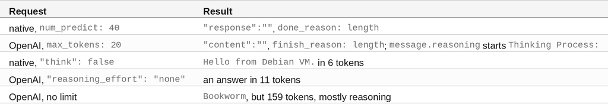

**Check `finish_reason` in your app, not just the status code.** Turn thinking off for quick answers, or leave room for the reasoning.

#### Which Model Fits in 8 GB

[figure not shown]

```bash
curl -s http://127.0.0.1:8000/api/generate -d '{"model":"gemma4:e2b-it-qat","keep_alive":0}'
```

#### Where the Split Pays Off

- **The app side is a real Debian server.** systemd, apt, sudo, a persistent disk, and your Mac source tree already mounted. Customize it, snapshot it with `mkdebian-machine publish`, and hand the image to someone else.
- **The model side is the Mac at full speed.** Metal, unified memory, no GPU passthrough to configure — because there is none to configure.
- **The seam is one URL.** `http://192.168.64.1:8000/v1` is an OpenAI-compatible endpoint. Point the same app at a different Ollama or llama.cpp server with `--url` and nothing in the VM changes.

The VM does the work that needs Linux. The Mac does the work that needs the GPU, and neither side pretends to be the other.

#### When Something Goes Wrong

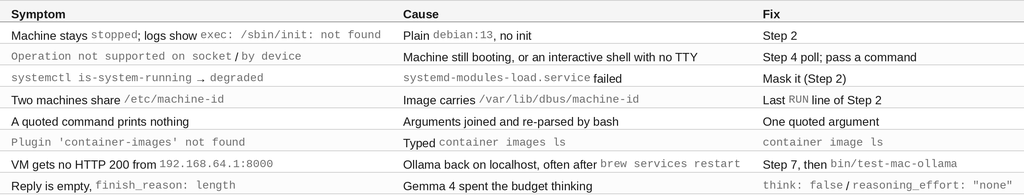

#### Cheat Sheet

```bash
# 0. install, start, kernel
container system start
container system kernel set --recommended

# 1. the official image cannot boot as a machine
container run --rm debian:13 sh -c 'ls -l /sbin/init'

# 2. build a Debian image with an init (Dockerfile above)
container builder start
container build -t debian13-machine .
container builder stop

# 3. check it
container run --rm debian13-machine sh -c 'ls -l /sbin/init; wc -c < /etc/machine-id'

# 4. create, then wait for it
container machine create debian13-machine --name dev-vm --cpus 2 --memory 2G
until container machine run -n dev-vm --root -- true 2>/dev/null; do sleep 2; done

# 5. check it
container machine run -n dev-vm -- 'systemctl is-system-running; id; sudo -n id -u'

# 6. customize it
container machine run -n dev-vm --root -- 'apt-get update && apt-get install -y git'

# 2-5, the short way
bin/mkdebian-machine new -t debian13-machine -m dev-vm -p sudo

# 7. Ollama on all interfaces, restarted with launchctl
/usr/libexec/PlistBuddy -c 'Set :EnvironmentVariables:OLLAMA_HOST 0.0.0.0:8000' ~/Library/LaunchAgents/homebrew.mxcl.ollama.plist
launchctl bootout gui/$(id -u)/homebrew.mxcl.ollama
launchctl bootstrap gui/$(id -u) ~/Library/LaunchAgents/homebrew.mxcl.ollama.plist

# 8. the Mac on its own
bin/test-mac-ollama

# 9. the model from the VM
container machine run -n dev-vm -- 'curl -s http://192.168.64.1:8000/v1/models'

# 10. the whole round trip
bin/test-vm-ollama -n dev-vm

# clean up
container machine stop dev-vm
container machine delete dev-vm
container image rm debian13-machine
```

#### Summary

The goal of this article was to get a persistent Debian 13 machine running under Apple's `container` CLI, and then let apps inside it use a local LLM on the Mac's GPU. The key to the solution was splitting the two: build an image the machine can actually boot, and leave the model on macOS where Metal is, reached over the VM network at `192.168.64.1`. The results were:

- 🟢 The official `debian:13` image cannot boot as a machine; adding `systemd-sysv` plus a machine-id scrub gives Debian 13 with systemd `running`, your Mac user and passwordless sudo
- 🟢 Packages installed in the machine survived a restart
- 🟢 From the VM, `gemma4:e2b` answered through the native, streaming and OpenAI-compatible APIs at 45.2 tok/s, loaded 100% on the GPU
- 🟢 `bin/test-mac-ollama` reported `10 passed, 0 failed` and `bin/test-vm-ollama` reported `8 passed, 0 failed`
- ⚠️ `brew services restart ollama` silently reverts Ollama to localhost, and the VM loses the model
- ⚠️ Gemma 4 returns an empty answer with a small token limit unless thinking is turned off

Scope: one Apple M3 Mac with 8 GB on macOS 27.0 (26A428), `container` 1.4.1, a Debian 13 machine with 2 CPUs and 2 GB, Ollama 0.33.3 with `OLLAMA_KV_CACHE_TYPE=q4_0` and flash attention on. Each throughput figure is a single run from the test scripts on 2026-09-13, and the model replies vary from run to run.

The strategy for running a customized Debian machine on Apple container with a local LLM on the Mac GPU was validated with an incremental step by step approach.

#### References

- [apple-container-debian-tips | GitHub](https://github.com/xbill9/apple-container-debian-tips)
- [apple/container | GitHub](https://github.com/apple/container)
- [Ollama](https://ollama.com)
- [Gemma 4 on Ollama](https://ollama.com/library/gemma4)